# CUNY SPS DATA607 Assignment 10 - Sentiment Analysis

### **Part II: Extend the Analysis to new corpus and new lexicon:**

In this part, we performed sentiment analysis on three books by James Hartwell from the gutenberg library. The three books are:

Title: “The Cat and the Mouse: A Book of Persian Fairy Tales”; EBook-No: 24473

Title: “The Enchanted Castle: A Book of Fairy Tales from Flowerland”; EBook-No: 27952

Title: “The Magic Bed: A Book of East Indian Fairy Tales”; EBook-No: 37708

Also, we implemented another lexicon `loughran` for sentiment analysis. This lexicon is by Tim Loughran and Bill McDonald of the University of Notre Dame and it labels words with six possible sentiments in financial contexts: “negative”, “positive”, “litigious”, “uncertainty”, “constraining”, or “superflous”. So, we filtered the Loughran lexicon to use only the “positive” and “negative” labeling. More details on this lexicon can be found [here](https://www.rdrr.io/cran/textdata/man/lexicon_loughran.html)

```r
# download the book "The Cat and the Mouse: A Book of Persian Fairy Tales" from project gutenberg
cat_mouse <- gutenberg_download(24473)
```

```
## Determining mirror for Project Gutenberg from http://www.gutenberg.org/robot/harvest
```

```
## Using mirror http://aleph.gutenberg.org
```

```r
names(cat_mouse) <- c("book", "text") # rename the column names so the gutenberg_id column is called book
cat_mouse$book <- "The Cat and the Mouse" # replace the gutenberg_id with the book name so it can be intuitive

# download the book "The Enchanted Castle: A Book of Fairy Tales from Flowerland" from project gutenberg
enchanted_castle <- gutenberg_download(27952)
names(enchanted_castle) <- c("book", "text") # rename the column names so the gutenberg_id column is called book
enchanted_castle$book <- "The Enchanted Castle"#replace the gutenberg_id with the book name so it can be intuitive

# download the book "The Magic Bed: A Book of East Indian Fairy Tales" from project gutenberg
magic_bed <- gutenberg_download(37708)
names(magic_bed) <- c("book", "text") # rename the column names so the gutenberg_id column is called book
magic_bed$book <- "The Magic Bed" # replace the gutenberg_id with the book name so it can be intuitive

# combine all three books into one dataset
james_hartwell <- rbind(cat_mouse, enchanted_castle, magic_bed)
james_hartwell
```

| book | text |
| --- | --- |
| The Cat and the Mouse | Persian Fairy Tales |
| The Cat and the Mouse |  |
| The Cat and the Mouse | Altemus' Fairy Tales Series |
| The Cat and the Mouse |  |
| The Cat and the Mouse | THE CAT AND THE MOUSE |
| The Cat and the Mouse |  |
| The Cat and the Mouse | A Book of Persian Fairy Tales |
| The Cat and the Mouse |  |
| The Cat and the Mouse | Edited with an Introduction by |
| The Cat and the Mouse |  |

[output cut: 3304 more lines]

*Get Another sentiment lexicon: “loughran”*

```r
# get loughran sentiment
library(tidyverse)
get_sentiments("loughran")
```

| word | sentiment |
| --- | --- |
| abandon | negative |
| abandoned | negative |
| abandoning | negative |
| abandonment | negative |
| abandonments | negative |
| abandons | negative |
| abdicated | negative |
| abdicates | negative |
| abdicating | negative |
| abdication | negative |

[output cut: 4140 more lines]

*Sentiment Analysis with inner join*

```r
# tokenize the texts from the three books by James Hartwell
james_hartwell_tidy_books <- james_hartwell %>% group_by(book) %>%
  mutate(
    linenumber = row_number(),
    chapter = cumsum(str_detect(text,
                                regex("^chapter [\\divxlc]", ignore_case = TRUE)))) %>%
  ungroup() %>% unnest_tokens(word, text)

# filter the joy words from the NRC lexicon
nrc_joy <- get_sentiments("nrc") %>% filter(sentiment == "joy")

# filter the tidy text dataframe in james_hartwell_tidy_books for words from "The Magic Bed"
james_hartwell_tidy_books %>% filter(book == "The Magic Bed") %>% inner_join(nrc_joy) %>%
  count(word, sort = TRUE)
```

| word | n |
| --- | --- |
| beautiful | 33 |
| tree | 31 |
| found | 12 |
| kind | 11 |
| daughter | 9 |
| baby | 8 |
| garden | 8 |
| lovely | 8 |
| marry | 8 |
| mother | 8 |

[output cut: 57 more lines]

```r
#james_hartwell_tidy_books
```

*Sentiment Analysis across all books by James Hartwell using the loughran lexicon*

```r
# get loughran sentiment and filter for only the positive and negative sentiments label
loughran_sentiments <- get_sentiments("loughran") %>% filter(sentiment %in% c("positive", "negative"))
# sentiment for James Hartwell books using the loughran lexicon
james_hartwell_sentiment <- james_hartwell_tidy_books %>% inner_join(loughran_sentiments) %>%
  count(book, index = linenumber %/% 80, sentiment) %>%
  pivot_wider(names_from = sentiment, values_from = n, values_fill = 0) %>%
  mutate(sentiment = positive - negative)
james_hartwell_sentiment
```

| book | index | positive | negative | sentiment |
| --- | --- | --- | --- | --- |
| The Cat and the Mouse | 0 | 5 | 0 | 5 |
| The Cat and the Mouse | 1 | 3 | 3 | 0 |
| The Cat and the Mouse | 2 | 5 | 7 | -2 |
| The Cat and the Mouse | 3 | 6 | 9 | -3 |
| The Cat and the Mouse | 4 | 2 | 12 | -10 |
| The Cat and the Mouse | 5 | 8 | 9 | -1 |
| The Cat and the Mouse | 6 | 10 | 20 | -10 |
| The Cat and the Mouse | 7 | 4 | 9 | -5 |
| The Cat and the Mouse | 8 | 15 | 1 | 14 |
| The Cat and the Mouse | 9 | 1 | 12 | -11 |

[output cut: 33 more lines]

*Visualize the sentiment across the plot trajectory of each book*

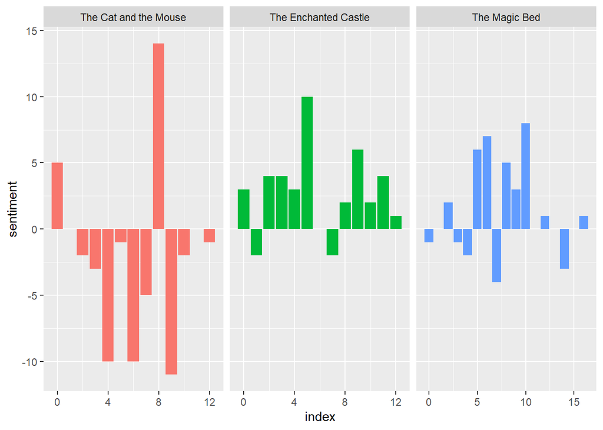

```r
ggplot(james_hartwell_sentiment, aes(index, sentiment, fill = book)) + geom_col(show.legend = FALSE) +
  facet_wrap(~book, ncol = 3, scales = "free_x")
```

There appears to be more negative sentiment for the book “The Cat and the Mouse” compared to other books by James Hartwell.

*Comparing the four different lexicons*  
In this section, I’ll use all four sentiment lexicons(“loughran”, “nrc”, “afinn”, and “bing”) to examine how the sentiment changes across the narrative arc of `The Cat and the Mouse`.

```r
# filter the tidy text dataframe "james_hartwell_tidy_books" for where book is "The Cat and the Mouse"
cat_and_mouse <- james_hartwell_tidy_books %>% filter(book == "The Cat and the Mouse")

# Using the "afinn" lexicon
afinn_cat_mouse <- cat_and_mouse %>% inner_join(get_sentiments("afinn")) %>%
  group_by(index = linenumber %/% 80) %>% summarise(sentiment = sum(value)) %>%
  mutate(method = "AFINN")
# Using the loughran, bing, and nrc lexicons
bing_and_nrc_and_loughran <- bind_rows(
  cat_and_mouse %>% inner_join(get_sentiments("bing")) %>% mutate(method = "BING et al."),
  cat_and_mouse %>% inner_join(get_sentiments("nrc") %>%
                                 filter(sentiment %in% c("positive", "negative"))) %>% mutate(method = "NRC"),
  cat_and_mouse %>% inner_join(get_sentiments("loughran") %>%
                                 filter(sentiment %in% c("positive", "negative"))) %>% mutate(method = "LOUGHRAN")
) %>%
  count(method, index = linenumber %/% 80, sentiment) %>%
  pivot_wider(names_from = sentiment, values_from = n, values_fill = 0) %>%
  mutate(sentiment = positive - negative)
```

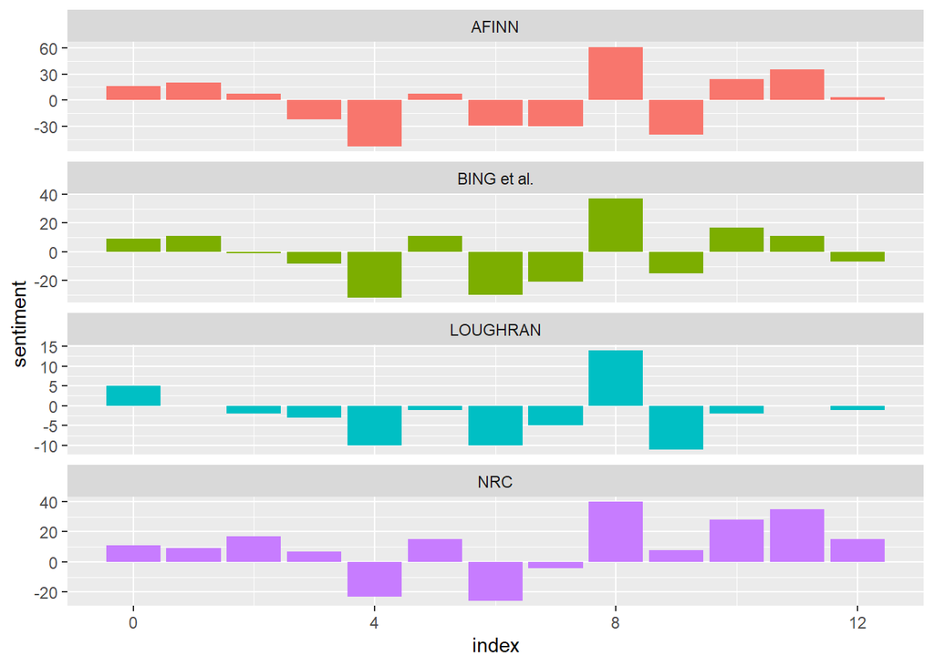

```r
# Bind all four lexicons together and visualize with ggplot
bind_rows(afinn_cat_mouse, bing_and_nrc_and_loughran) %>% ggplot(aes(index, sentiment, fill = method)) +
  geom_col(show.legend = FALSE) + facet_wrap(~method, ncol = 1, scales = "free_y")
```

From the sentiment analysis, the four(4) different lexicons give results that are different in absolute sense, but have similar trajectories through the book. We can see similar dips and peaks in sentiment at about the same locations in the book, but the absolute values of the sentiment are significantly different with the “AFINN” lexicon having the greatest absolute values with high positive values, while the lexicon from “LOUGHRAN” has the lowest absolute values. These differences in absolute values could be as a result of the differences in the number of positive or negative sentiment words in each lexicon.

```r
# count of negative and positive sentiment in loughran lexicon
get_sentiments("loughran") %>% filter(sentiment %in% c("positive", "negative")) %>%
  count(sentiment) %>% mutate(prop = round(n*100/sum(n),2))
```

| sentiment | n | prop |
| --- | --- | --- |
| negative | 2355 | 86.93 |
| positive | 354 | 13.07 |

```r
# count of negative and positive sentiment in nrc lexicon
get_sentiments("nrc") %>% filter(sentiment %in% c("positive", "negative")) %>%
  count(sentiment) %>% mutate(prop = round(n*100/sum(n),2))
```

| sentiment | n | prop |
| --- | --- | --- |
| negative | 3318 | 58.98 |
| positive | 2308 | 41.02 |

```r
# count of negative and positive sentiment in bing lexicon
get_sentiments("bing") %>% count(sentiment) %>% mutate(prop = round(n*100/sum(n),2))
```

| sentiment | n | prop |
| --- | --- | --- |
| negative | 4781 | 70.45 |
| positive | 2005 | 29.55 |

Looking at the count for positive and negative words in the “nrc”, “loughran”, and “bing” lexicons, we see that there are more negative words in all three(3) lexicons with the loughran lexicon having the least absolute number of negative words, but a significantly greater proportion of negative words compared to other lexicons.

*Most common positive and negative words*

```r
# Using the bing lexicon
bing_word_counts_cats <- james_hartwell_tidy_books %>% inner_join(get_sentiments("bing")) %>%
  count(word, sentiment, sort = TRUE) %>% ungroup()
bing_word_counts_cats
```

| word | sentiment | n |
| --- | --- | --- |
| beautiful | positive | 65 |
| like | positive | 56 |
| great | positive | 53 |
| love | positive | 36 |
| gold | positive | 31 |
| poor | negative | 24 |
| good | positive | 23 |
| sweet | positive | 22 |
| fell | negative | 21 |
| golden | positive | 20 |

[output cut: 506 more lines]

*Visualizing this with ggplot2*

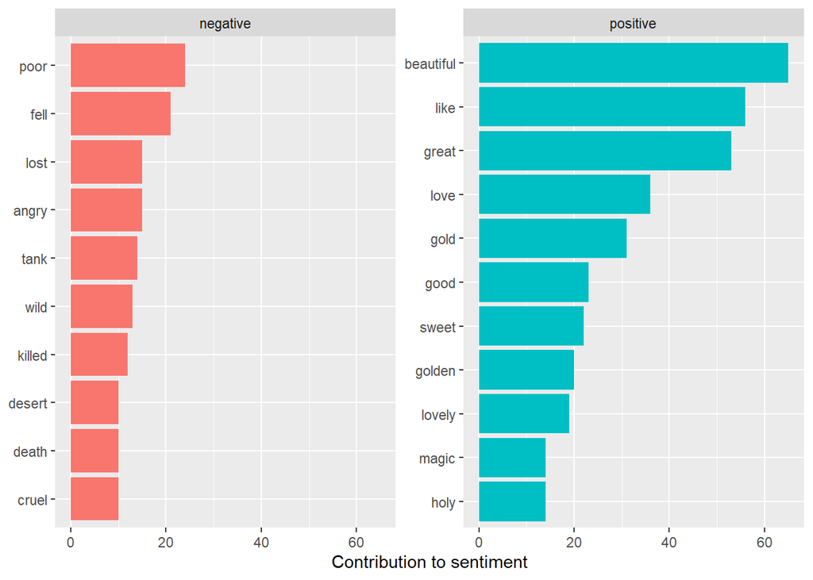

```r
bing_word_counts_cats %>% group_by(sentiment) %>% slice_max(n,n =10) %>% ungroup() %>%
  mutate(word = reorder(word, n)) %>% ggplot(aes(n, word, fill = sentiment)) + geom_col(show.legend = FALSE) +
  facet_wrap(~sentiment, scales = "free_y") + labs(x = "Contribution to sentiment", y = NULL)
```

*We can also find out how each word contributes to each sentiment using the Loughran lexicon*

```r
# using the loughran lexicon
loughran_word_counts_cats <- james_hartwell_tidy_books %>% inner_join(loughran_sentiments) %>%
  count(word, sentiment, sort = TRUE) %>% ungroup()
loughran_word_counts_cats
```

| word | sentiment | n |
| --- | --- | --- |
| beautiful | positive | 65 |
| great | positive | 53 |
| poor | negative | 24 |
| good | positive | 23 |
| lost | negative | 15 |
| better | positive | 11 |
| dropped | negative | 9 |
| fear | negative | 8 |
| pleased | positive | 8 |
| happy | positive | 7 |

[output cut: 129 more lines]

*Visualizing this with ggplot2:*

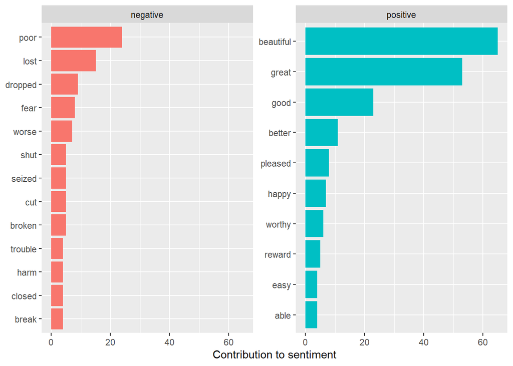

```r
loughran_word_counts_cats %>% group_by(sentiment) %>% slice_max(n,n =10) %>% ungroup() %>%
  mutate(word = reorder(word, n)) %>% ggplot(aes(n, word, fill = sentiment)) + geom_col(show.legend = FALSE) +
  facet_wrap(~sentiment, scales = "free_y") + labs(x = "Contribution to sentiment", y = NULL)
```

*Wordcloud*  
In this section, we consider the most common words in James Hartwell three books being considered in this analysis as a whole, but this time as a wordcloud.

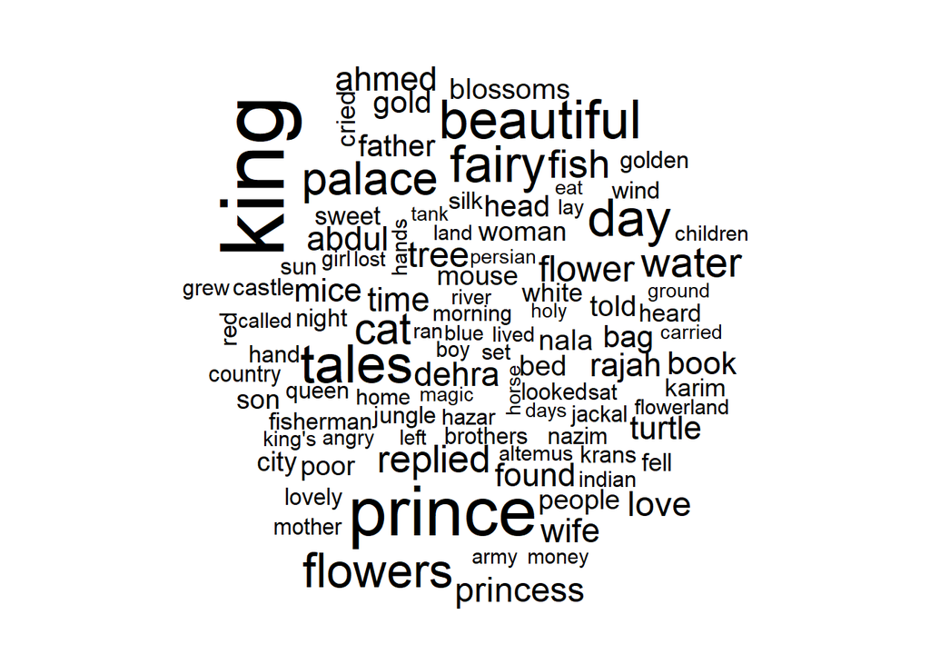

```r
# word cloud of most common words in James Hartwell's three books
james_hartwell_tidy_books %>% anti_join(stop_words) %>% count(word) %>%
  with(wordcloud(word, n, max.words = 100))
```

Using a different function like `comparison.cloud()` to visualize the wordcloud, as before, we first convert the dataframe into a matrix by using the `acast()` function from the reshape2 package.

*wordcloud using the bing lexicon*

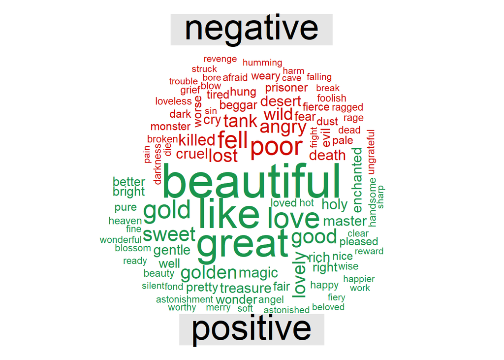

```r
# using the bing lexicon
james_hartwell_tidy_books %>% inner_join(get_sentiments("bing")) %>%
  count(word, sentiment, sort = TRUE) %>% acast(word ~ sentiment, value.var = "n", fill = 0) %>%
  comparison.cloud(color = c("#cf0a00","#1a954d"), max.words = 100)
```

*wordcloud using the loughran lexicon*

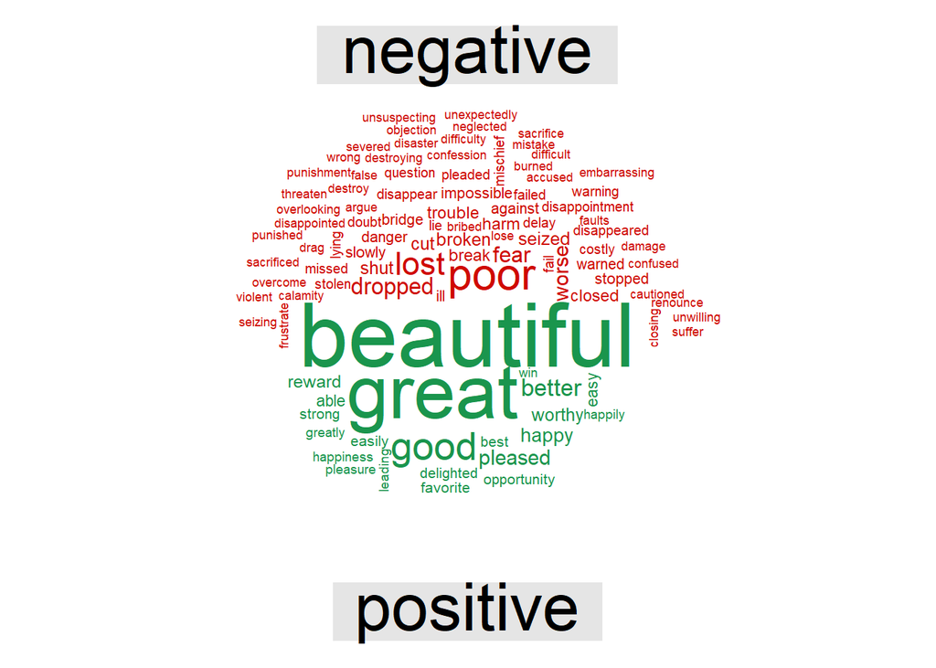

```r
# using the bing lexicon
james_hartwell_tidy_books %>% inner_join(loughran_sentiments) %>%
  count(word, sentiment, sort = TRUE) %>% acast(word ~ sentiment, value.var = "n", fill = 0) %>%
  comparison.cloud(color = c("#cf0a00","#1a954d"), max.words = 100)
```